# Bank Modelling_Decodr_15-Jun-2020-Final_Submission_Debasish_Goswami

```python
print(df2_log['Income'].describe())
```

```
count    5000.000000
mean       73.770550
std        46.022375
min         8.000000
25%        39.000000
50%        64.000000
75%        98.000000
max       211.875388
Name: Income, dtype: float64
```

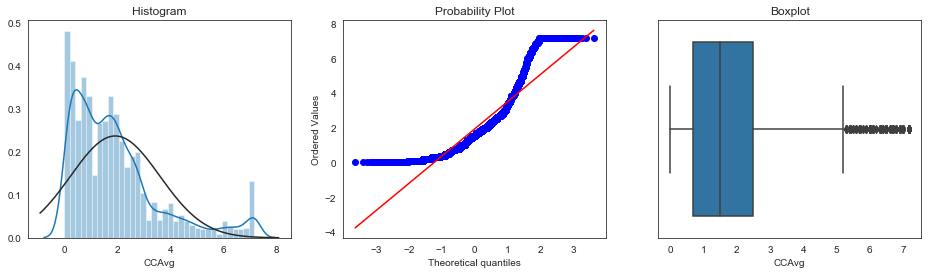

```python
plt.figure(figsize=(16,4))
plt.subplot(1,3,1)
sns.set_style('white')
sns.distplot(df2_log['CCAvg'],fit=norm)
plt.title('Histogram')
plt.subplot(1,3,2)
stats.probplot(df2_log['CCAvg'],dist='norm',plot=plt)
plt.subplot(1,3,3)
sns.boxplot(df2_log['CCAvg'])
plt.title('Boxplot')
plt.show()
```

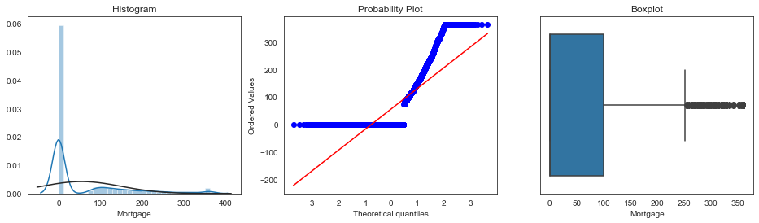

```python
plt.figure(figsize=(16,4))
plt.subplot(1,3,1)
sns.set_style('white')
sns.distplot(df2_log['Mortgage'],fit=norm)
plt.title('Histogram')
plt.subplot(1,3,2)
stats.probplot(df2_log['Mortgage'],dist='norm',plot=plt)
plt.subplot(1,3,3)
sns.boxplot(df2_log['Mortgage'])
plt.title('Boxplot')
plt.show()
```

**We're taking Log transformation of the variables where presence of outlers are expected.**

```python
df2_log['Income']=np.log(df2_log[df2_log['Income']>0]['Income'])
df2_log['Income'].fillna(0,inplace=True)
```

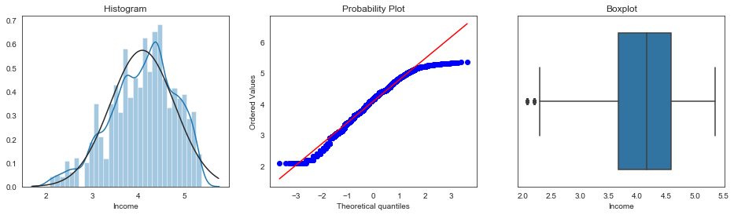

```python
plt.figure(figsize=(16,4))
plt.subplot(1,3,1)
sns.set_style('white')
sns.distplot(df2_log['Income'],fit=norm)
plt.title('Histogram')
plt.subplot(1,3,2)
stats.probplot(df2_log['Income'],dist='norm',plot=plt)
plt.subplot(1,3,3)
sns.boxplot(df2_log['Income'])
plt.title('Boxplot')
plt.show()
```

```python
df2_log['CCAvg']=np.log(df2_log[df2_log['CCAvg']>0]['CCAvg'])
df2_log['CCAvg'].fillna(0,inplace=True)
```

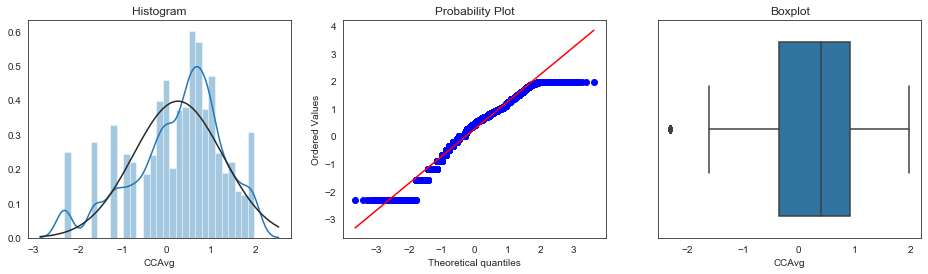

```python
plt.figure(figsize=(16,4))
plt.subplot(1,3,1)
sns.set_style('white')
sns.distplot(df2_log['CCAvg'],fit=norm)
plt.title('Histogram')
plt.subplot(1,3,2)
stats.probplot(df2_log['CCAvg'],dist='norm',plot=plt)
plt.subplot(1,3,3)
sns.boxplot(df2_log['CCAvg'])
plt.title('Boxplot')
plt.show()
```

```python
df2_log['Mortgage']=np.log(df2_log[df2_log['Mortgage']>0]['Mortgage'])
df2_log['Mortgage'].fillna(0,inplace=True)
```

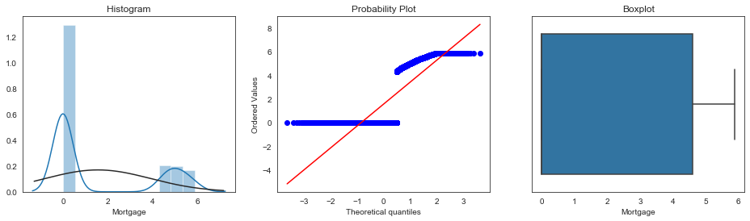

```python
plt.figure(figsize=(16,4))
plt.subplot(1,3,1)
sns.set_style('white')
sns.distplot(df2_log['Mortgage'],fit=norm)
plt.title('Histogram')
plt.subplot(1,3,2)
stats.probplot(df2_log['Mortgage'],dist='norm',plot=plt)
plt.subplot(1,3,3)
sns.boxplot(df2_log['Mortgage'])
plt.title('Boxplot')
plt.show()
```

- Income and CCAVG is now looking comparatively good with respect to Normal Distribution
- We are removing below variable from our model building:
  > > - mortgage:Its showing high P value in model so with 95% confidence it is said that the variable is insignificant for our model.
  > > - family:Its showing high P value in model so with 95% confidence it is said that the variable is insignificant for our model.
  > > - experience:Its having veri high co-relation with Age, so its not adding any dditional value to our model.
  > > - ID:Customer ID has nothing to do with target variable.
  > > - Zip code:Its just an indicator of the Address of customer and i didn't find any value addition in this variable.

```python
x=df2_log.drop(['Personal Loan','ID','Experience','ZIP Code','Mortgage','Family'],axis=1)
y=df2_log['Personal Loan']
```

```python
x.columns
```

```
Index(['Age', 'Income', 'CCAvg', 'Education', 'Securities Account',
       'CD Account', 'Online', 'CreditCard'],
      dtype='object')
```

### Splitting our dataset into Training and test set:

```python
from sklearn.model_selection import train_test_split
xtrain,xtest,ytrain,ytest=train_test_split(x,y,test_size=0.2)
```

## Logistic Model:

```python
import statsmodels.api as sm
model=sm.Logit(ytrain,xtrain)
```

```python
result=model.fit()
result.summary()
```

```
Optimization terminated successfully.
         Current function value: 0.242442
         Iterations 8
```

Logit Regression Results

| Dep. Variable: | Personal Loan | No. Observations: | 4000 |
| --- | --- | --- | --- |
| Model: | Logit | Df Residuals: | 3992 |
| Method: | MLE | Df Model: | 7 |
| Date: | Sun, 21 Jun 2020 | Pseudo R-squ.: | 0.2305 |
| Time: | 22:03:17 | Log-Likelihood: | -969.77 |
| converged: | True | LL-Null: | -1260.3 |
| Covariance Type: | nonrobust | LLR p-value: | 2.835e-121 |

|  | coef | std err | z | P>\|z\| | [0.025 | 0.975] |
| --- | --- | --- | --- | --- | --- | --- |
| Age | -0.0524 | 0.005 | -10.115 | 0.000 | -0.063 | -0.042 |
| Income | -0.2614 | 0.065 | -4.049 | 0.000 | -0.388 | -0.135 |
| CCAvg | 1.3711 | 0.104 | 13.189 | 0.000 | 1.167 | 1.575 |
| Education | 0.3903 | 0.068 | 5.764 | 0.000 | 0.258 | 0.523 |
| Securities Account | -1.4468 | 0.242 | -5.982 | 0.000 | -1.921 | -0.973 |
| CD Account | 3.9851 | 0.254 | 15.686 | 0.000 | 3.487 | 4.483 |
| Online | -0.7339 | 0.127 | -5.786 | 0.000 | -0.983 | -0.485 |
| CreditCard | -1.4164 | 0.182 | -7.766 | 0.000 | -1.774 | -1.059 |

```python
from sklearn.linear_model import LogisticRegression
lm=LogisticRegression()
lm.fit(xtrain,ytrain)
```

```
LogisticRegression(C=1.0, class_weight=None, dual=False, fit_intercept=True,
                   intercept_scaling=1, l1_ratio=None, max_iter=100,
                   multi_class='warn', n_jobs=None, penalty='l2',
                   random_state=None, solver='warn', tol=0.0001, verbose=0,
                   warm_start=False)
```

```python
ypred_test=lm.predict(xtest)
ypred_train=lm.predict(xtrain)
#data={'ytest':ytest,'ypred':ypred}
#pre=pd.DataFrame(data,columns=['ytest','ypred'])
#pre.to_csv('C:/Debasish/personal/DS_city/Decodr Assignments/15-Jun-2020/Pre1.csv',index=None)
```

```python
from sklearn.metrics import confusion_matrix,classification_report

print("Test Summary\n")
print(classification_report(ytest,ypred_test))
print(confusion_matrix(ytest,ypred_test))
print('\n')
print("*"*50)
print("\nTrain Summary\n")
print(classification_report(ytrain,ypred_train))
print(confusion_matrix(ytrain,ypred_train))
```

```
Test Summary

              precision    recall  f1-score   support

           0       0.94      1.00      0.97       902
           1       0.97      0.40      0.57        98

    accuracy                           0.94      1000
   macro avg       0.96      0.70      0.77      1000
weighted avg       0.94      0.94      0.93      1000

[[901   1]
 [ 59  39]]



Train Summary

              precision    recall  f1-score   support

           0       0.95      0.99      0.97      3618
           1       0.89      0.46      0.60       382

    accuracy                           0.94      4000
   macro avg       0.92      0.73      0.79      4000
weighted avg       0.94      0.94      0.93      4000

[[3596   22]
 [ 207  175]]
```

```
0.6984252681116793
0.7260172378364141
```

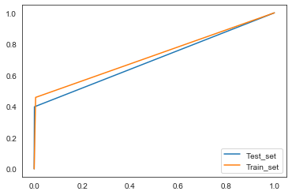

```python
import sklearn
from sklearn import metrics
from sklearn.metrics import roc_auc_score
fpr,tpr,thresholds=sklearn.metrics.roc_curve(ytest,ypred_test)
plt.plot(fpr,tpr,label='Test_set')
fpr1,tpr1,thresholds1=sklearn.metrics.roc_curve(ytrain,ypred_train)
plt.plot(fpr1,tpr1,label='Train_set')
print(metrics.auc(fpr, tpr))
print(metrics.auc(fpr1, tpr1))
plt.legend(loc="lower right")
```